# Access collections from xcube geodb

## How to use xcube geoDB and explore available DeepESDL data

This notebook demonstrates how to make use of feature data stored in xcube geoDB.

Please, also refer to the [DeepESDL documentation](https://deepesdl.readthedocs.io/en/latest/guide/jupyterlab/) and visit the platform's [website](https://www.earthsystemdatalab.net/) for further information!

Brockmann Consult, 2025

**This notebook runs with the python environment `users-deepesdl-xcube-1.9.1`, please checkout the documentation for [help on changing the environment](https://deepesdl.readthedocs.io/en/latest/guide/jupyterlab/#python-environment-selection-of-the-jupyter-kerne).**

```python
# import xcube geoDB library
from xcube_geodb.core.geodb import GeoDBClient
```

# import xcube geoDB library from xcube_geodb.core.geodb import GeoDBClient

```python
# utility needed for plotting
import matplotlib.pyplot as plt
```

# utility needed for plotting import matplotlib.pyplot as plt

**Please note:** In order to access data from xcube geoDB, you need credentials.  
**If you want to store feature data in xcubes geoDB or access existing data, please contact the DeepESDL team :)**  
If the DeepESDL team has created access for you already, your credentials are saved as env variables.

```python
# Connect to the xcube geodatabase.
geodb = GeoDBClient()
```

# Connect to the xcube geodatabase. geodb = GeoDBClient()

Access available databases for deep-esdl to your xcube geoDB user. The below cell filters all databases for deep-esdl. **Currently no data is shared publicly for all DeepESDL users, so the output will be empty if you don't belong to a team that has included data into xcube geoDB.**

```python
df = geodb.get_my_collections()
deepesdl_collections = df[df["database"].str.contains("deep-esdl")==True]
```

df = geodb.get_my_collections() deepesdl_collections = df[df["database"].str.contains("deep-esdl")==True]

```python
deepesdl_collections
```

deepesdl_collections

|  | owner | database | collection |
| --- | --- | --- | --- |

However, lets have look at a publicly accessible collection to explore the functionality of xcube geodb.

### How to accesss EEA Urban Atlas Data

The full statistical validation of Urban Atlas 2018 hasn't been performed yet. The European Environment Agency accepts no responsibility or liability whatsoever with regard to use of the non-validated Urban Atlas 2018 data.

To view other publicly available data stored in xcube geoDB:

```python
df = geodb.get_my_collections()
df
```

df = geodb.get_my_collections() df

|  | owner | database | collection |
| --- | --- | --- | --- |
| 0 | geodb_mgec | DOORS_Cruise_1_MGEC | Lithological_types |
| 1 | geodb_mgec | DOORS_Cruise_1_MGEC | Microplastic_from_sediments |
| 2 | geodb_mgec | DOORS_Cruise_1_MGEC | Water_containe_Bulk_density |
| 3 | geodb_mgec | DOORS_Cruise_2_Leg_2_MGEC_GeoEcoMar | Geochemical_ICPMS |
| 4 | geodb_mgec | DOORS_Cruise_2_Leg_2_MGEC_GeoEcoMar | Geochemical_XRF |
| ... | ... | ... | ... |
| 947 | geodb_b34bfae7-9265-4a3e-b921-06549d3c6035 | stac_test | ge_train_tier_2_labels |
| 948 | geodb_b34bfae7-9265-4a3e-b921-06549d3c6035 | stac_test | ge_train_tier_2_source |
| 949 | geodb_b34bfae7-9265-4a3e-b921-06549d3c6035 | stac_test | ties_ai_challenge_test |
| 950 | geodb_d2c4722a-cc19-4ec1-b575-0cdb6876d4a7 | test_duplicate | test |
| 951 | None | None | None |

952 rows × 3 columns

Access a collection which is concerning EEA Urban Atlas data:

```python
ds = geodb.get_my_collections(database='eea-urban-atlas')
ds
```

ds = geodb.get_my_collections(database='eea-urban-atlas') ds

|  | owner | database | collection |
| --- | --- | --- | --- |
| 0 | geodb_admin | eea-urban-atlas | AL001L1_TIRANA_UA2018 |
| 1 | geodb_admin | eea-urban-atlas | AL003L1_ELBASAN_UA2018 |
| 2 | geodb_admin | eea-urban-atlas | AL004L1_SHKODER_UA2018 |
| 3 | geodb_admin | eea-urban-atlas | AL005L0_VLORE_UA2018 |
| 4 | geodb_admin | eea-urban-atlas | AT001L3_WIEN_UA2018 |
| ... | ... | ... | ... |
| 784 | geodb_admin | eea-urban-atlas | UK569L2_IPSWICH_UA2018 |
| 785 | geodb_admin | eea-urban-atlas | UK571L1_CHELTENHAM_UA2018 |
| 786 | geodb_admin | eea-urban-atlas | XK001L1_PRISTINA_UA2018 |
| 787 | geodb_admin | eea-urban-atlas | XK002L1_PRIZREN_UA2018 |
| 788 | geodb_admin | eea-urban-atlas | XK003L1_MITROVICE_UA2018 |

789 rows × 3 columns

In the table 'METADATA' you can find a list of all collections with a link to the corresponding metadata xml. A METADATA table might not be available for other databases.

```python
metadata = geodb.get_collection('METADATA', database='eea-urban-atlas')
metadata
```

metadata = geodb.get_collection('METADATA', database='eea-urban-atlas') metadata

|  | id | created_at | modified_at | geometry | table_name | disclaimer | metadata_url |
| --- | --- | --- | --- | --- | --- | --- | --- |
| 0 | 1 | 2021-03-10T11:35:20.29555+00:00 | None | POINT (0 0) | EL004L1_IRAKLEIO_UA2018 | The full statistical validation of Urban Atlas... | https://edc-eea-urban-atlas.s3.eu-central-1.am... |
| 1 | 2 | 2021-03-10T11:35:20.29555+00:00 | None | POINT (0 0) | RO509L1_SATU_MARE_UA2018 | The full statistical validation of Urban Atlas... | https://edc-eea-urban-atlas.s3.eu-central-1.am... |
| 2 | 3 | 2021-03-10T11:35:20.29555+00:00 | None | POINT (0 0) | PL018L2_ZIELONA_GORA_UA2018 | The full statistical validation of Urban Atlas... | https://edc-eea-urban-atlas.s3.eu-central-1.am... |
| 3 | 4 | 2021-03-10T11:35:20.29555+00:00 | None | POINT (0 0) | UK009L1_CARDIFF_UA2018 | The full statistical validation of Urban Atlas... | https://edc-eea-urban-atlas.s3.eu-central-1.am... |
| 4 | 5 | 2021-03-10T11:35:20.29555+00:00 | None | POINT (0 0) | TR046L1_RIZE_UA2018 | The full statistical validation of Urban Atlas... | https://edc-eea-urban-atlas.s3.eu-central-1.am... |
| ... | ... | ... | ... | ... | ... | ... | ... |
| 783 | 781 | 2021-03-10T11:35:20.29555+00:00 | None | POINT (0 0) | SE505L1_BORAS_UA2018 | The full statistical validation of Urban Atlas... | https://edc-eea-urban-atlas.s3.eu-central-1.am... |
| 784 | 782 | 2021-03-10T11:35:20.29555+00:00 | None | POINT (0 0) | HU006L2_SZEGED_UA2018 | The full statistical validation of Urban Atlas... | https://edc-eea-urban-atlas.s3.eu-central-1.am... |
| 785 | 783 | 2021-03-10T11:35:20.29555+00:00 | None | POINT (0 0) | BG002L2_PLOVDIV_UA2018 | The full statistical validation of Urban Atlas... | https://edc-eea-urban-atlas.s3.eu-central-1.am... |
| 786 | 787 | 2021-03-10T11:35:20.29555+00:00 | None | POINT (0 0) | ES003L3_VALENCIA_UA2018 | The full statistical validation of Urban Atlas... | https://edc-eea-urban-atlas.s3.eu-central-1.am... |
| 787 | 788 | 2021-03-10T11:35:20.29555+00:00 | None | POINT (0 0) | RO022L1_BISTRITA_UA2018 | The full statistical validation of Urban Atlas... | https://edc-eea-urban-atlas.s3.eu-central-1.am... |

788 rows × 7 columns

Let's checkout the metadata for Hamburg:

```python
metadata.loc[metadata['table_name'] == 'DE002L1_HAMBURG_UA2018']
```

metadata.loc[metadata['table_name'] == 'DE002L1_HAMBURG_UA2018']

|  | id | created_at | modified_at | geometry | table_name | disclaimer | metadata_url |
| --- | --- | --- | --- | --- | --- | --- | --- |
| 669 | 668 | 2021-03-10T11:35:20.29555+00:00 | None | POINT (0 0) | DE002L1_HAMBURG_UA2018 | The full statistical validation of Urban Atlas... | https://edc-eea-urban-atlas.s3.eu-central-1.am... |

```python
data_hh = geodb.get_collection_pg('DE002L1_HAMBURG_UA2018', database='eea-urban-atlas')
data_hh
```

data_hh = geodb.get_collection_pg('DE002L1_HAMBURG_UA2018', database='eea-urban-atlas') data_hh

|  | id | created_at | modified_at | geometry | country | fua_name | fua_code | code_2018 | class_2018 | prod_date | identifier | perimeter | area | comment |
| --- | --- | --- | --- | --- | --- | --- | --- | --- | --- | --- | --- | --- | --- | --- |
| 0 | 1 | 2021-03-02T09:42:42.07546+00:00 | None | MULTIPOLYGON (((4313681.147 3358339.107, 43136... | DE | Hamburg | DE002L1 | 11210 | Discontinuous dense urban fabric (S.L. : 50% -... | 2020-06 | 8738-DE002L1 | 136.705206 | 1053.511488 | None |
| 1 | 2 | 2021-03-02T09:42:42.07546+00:00 | None | MULTIPOLYGON (((4286000 3386090.175, 4285988.6... | DE | Hamburg | DE002L1 | 11210 | Discontinuous dense urban fabric (S.L. : 50% -... | 2020-06 | 14614-DE002L1 | 3036.494939 | 78551.793270 | None |
| 2 | 3 | 2021-03-02T09:42:42.07546+00:00 | None | MULTIPOLYGON (((4313000 3385378.38, 4313079.61... | DE | Hamburg | DE002L1 | 12100 | Industrial, commercial, public, military and p... | 2020-06 | 41718-DE002L1 | 2902.369992 | 128039.625423 | None |
| 3 | 4 | 2021-03-02T09:42:42.07546+00:00 | None | MULTIPOLYGON (((4336445.628 3378746.092, 43364... | DE | Hamburg | DE002L1 | 11210 | Discontinuous dense urban fabric (S.L. : 50% -... | 2020-06 | 12579-DE002L1 | 3491.080254 | 106401.321126 | None |
| 4 | 5 | 2021-03-02T09:42:42.07546+00:00 | None | MULTIPOLYGON (((4327413.933 3382235.972, 43273... | DE | Hamburg | DE002L1 | 11100 | Continuous urban fabric (S.L. : > 80%) | 2020-06 | 2191-DE002L1 | 171.049974 | 1721.083818 | None |
| ... | ... | ... | ... | ... | ... | ... | ... | ... | ... | ... | ... | ... | ... | ... |
| 75878 | 75879 | 2021-03-02T09:46:22.184492+00:00 | None | MULTIPOLYGON (((4349391.84 3384947.19, 4349381... | DE | Hamburg | DE002L1 | 31000 | Forests | 2020-06 | 74168-DE002L1 | 1236.112475 | 33920.248741 | None |
| 75879 | 75880 | 2021-03-02T09:46:22.184492+00:00 | None | MULTIPOLYGON (((4341241.425 3387281.552, 43412... | DE | Hamburg | DE002L1 | 31000 | Forests | 2020-06 | 74482-DE002L1 | 4935.325690 | 452405.287895 | None |
| 75880 | 75881 | 2021-03-02T09:46:22.184492+00:00 | None | MULTIPOLYGON (((4359519.682 3395155.954, 43594... | DE | Hamburg | DE002L1 | 40000 | Wetlands | 2020-06 | 74611-DE002L1 | 1009.438947 | 23861.015193 | None |
| 75881 | 75882 | 2021-03-02T09:46:22.184492+00:00 | None | MULTIPOLYGON (((4321000 3382076.364, 4320988.6... | DE | Hamburg | DE002L1 | 50000 | Water | 2020-06 | 75629-DE002L1 | 848.674936 | 21765.647478 | None |
| 75882 | 75883 | 2021-03-02T09:46:22.184492+00:00 | None | MULTIPOLYGON (((4363754.913 3380634.246, 43638... | DE | Hamburg | DE002L1 | 50000 | Water | 2020-06 | 75797-DE002L1 | 874.689690 | 30695.895634 | None |

75883 rows × 14 columns

Are you eager to vizualise the data? Here we go, import matplotlib first and then you can go ahead and plot the data. Again - it takes a few moments, after all there are 75883 polygons in the data :)

```python
fig, ax = plt.subplots(1, 1, figsize=(20,18))
data_hh.plot(column="code_2018", cmap="tab20", ax=ax, legend=True)
```

fig, ax = plt.subplots(1, 1, figsize=(20,18)) data_hh.plot(column="code_2018", cmap="tab20", ax=ax, legend=True)

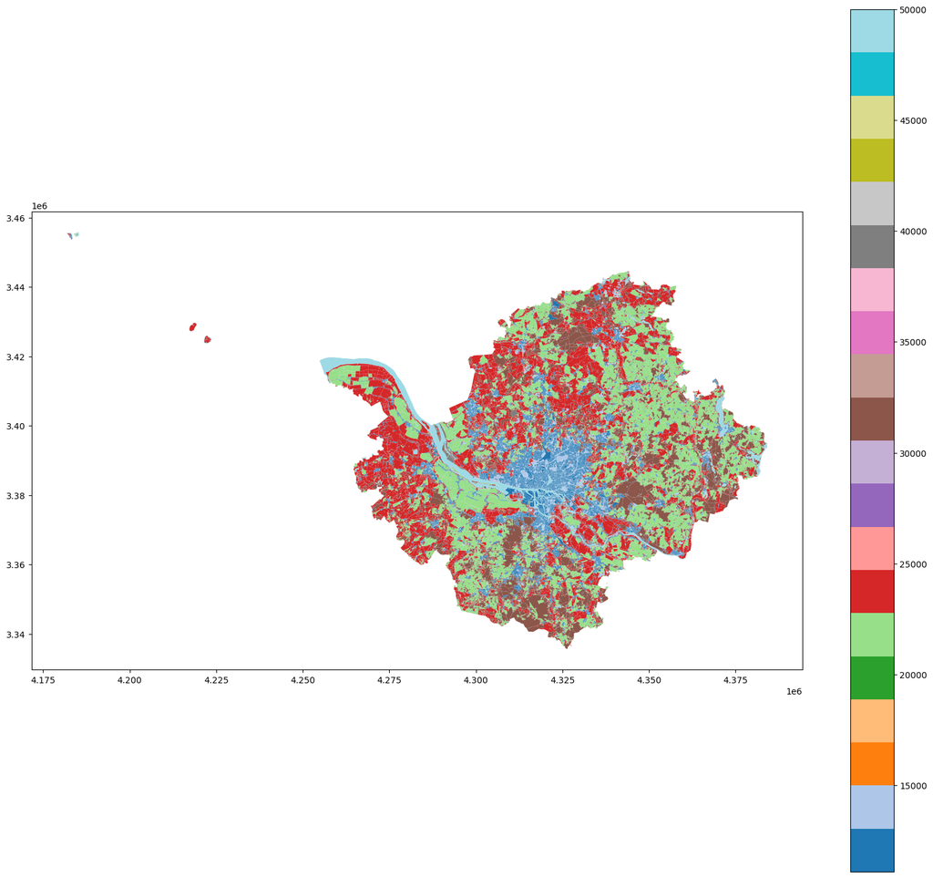

```python
geodb.get_event_log('DE002L1_HAMBURG_UA2018', database='eea-urban-atlas')
```

geodb.get_event_log('DE002L1_HAMBURG_UA2018', database='eea-urban-atlas')

|  | event_type | message | username | date |
| --- | --- | --- | --- | --- |
| 0 | read | read from collection eea-urban-atlas_DE002L1_H... | geodb_deepesdl-cubegen | 2025-05-12T12:37:53.925136 |
| 1 | read | read from collection eea-urban-atlas_DE002L1_H... | geodb_deepesdl-cubegen | 2025-05-22T10:34:07.590393 |